# Risk Factor Analysis

## Outcome Variable

**Outcome Variable:** y_rate_haz

## Predictor Variables

**Intervention Variable:** nchldlt5

**Adjustment Set:**

unadjusted

## Stratifying Variables

The analysis was stratified on these variable(s):

- diffcat
- studyid
- country

## Data Summary

| diffcat | studyid | country | nchldlt5 | n_cell | n |
| --- | --- | --- | --- | --- | --- |
| 0-3 months | ki1017093b-PROVIDE | BANGLADESH | 1 | 467 | 634 |
| 0-3 months | ki1017093b-PROVIDE | BANGLADESH | 2 | 158 | 634 |
| 0-3 months | ki1017093b-PROVIDE | BANGLADESH | 3+ | 9 | 634 |
| 3-6 months | ki1017093b-PROVIDE | BANGLADESH | 1 | 421 | 574 |
| 3-6 months | ki1017093b-PROVIDE | BANGLADESH | 2 | 145 | 574 |
| 3-6 months | ki1017093b-PROVIDE | BANGLADESH | 3+ | 8 | 574 |
| 6-12 months | ki1017093b-PROVIDE | BANGLADESH | 1 | 399 | 545 |
| 6-12 months | ki1017093b-PROVIDE | BANGLADESH | 2 | 138 | 545 |
| 6-12 months | ki1017093b-PROVIDE | BANGLADESH | 3+ | 8 | 545 |
| 12-24 months | ki1017093b-PROVIDE | BANGLADESH | 1 | 331 | 458 |
| 12-24 months | ki1017093b-PROVIDE | BANGLADESH | 2 | 121 | 458 |
| 12-24 months | ki1017093b-PROVIDE | BANGLADESH | 3+ | 6 | 458 |
| 0-3 months | ki1017093c-NIH-Crypto | BANGLADESH | 1 | 511 | 720 |
| 0-3 months | ki1017093c-NIH-Crypto | BANGLADESH | 2 | 203 | 720 |
| 0-3 months | ki1017093c-NIH-Crypto | BANGLADESH | 3+ | 6 | 720 |
| 3-6 months | ki1017093c-NIH-Crypto | BANGLADESH | 1 | 492 | 695 |
| 3-6 months | ki1017093c-NIH-Crypto | BANGLADESH | 2 | 198 | 695 |
| 3-6 months | ki1017093c-NIH-Crypto | BANGLADESH | 3+ | 5 | 695 |
| 6-12 months | ki1017093c-NIH-Crypto | BANGLADESH | 1 | 474 | 676 |
| 6-12 months | ki1017093c-NIH-Crypto | BANGLADESH | 2 | 198 | 676 |
| 6-12 months | ki1017093c-NIH-Crypto | BANGLADESH | 3+ | 4 | 676 |
| 12-24 months | ki1017093c-NIH-Crypto | BANGLADESH | 1 | 341 | 495 |
| 12-24 months | ki1017093c-NIH-Crypto | BANGLADESH | 2 | 151 | 495 |
| 12-24 months | ki1017093c-NIH-Crypto | BANGLADESH | 3+ | 3 | 495 |
| 0-3 months | kiGH5241-JiVitA-3 | BANGLADESH | 1 | 12472 | 20027 |
| 0-3 months | kiGH5241-JiVitA-3 | BANGLADESH | 2 | 7095 | 20027 |
| 0-3 months | kiGH5241-JiVitA-3 | BANGLADESH | 3+ | 460 | 20027 |
| 3-6 months | kiGH5241-JiVitA-3 | BANGLADESH | 1 | 8102 | 12571 |
| 3-6 months | kiGH5241-JiVitA-3 | BANGLADESH | 2 | 4211 | 12571 |
| 3-6 months | kiGH5241-JiVitA-3 | BANGLADESH | 3+ | 258 | 12571 |
| 6-12 months | kiGH5241-JiVitA-3 | BANGLADESH | 1 | 6298 | 9831 |
| 6-12 months | kiGH5241-JiVitA-3 | BANGLADESH | 2 | 3328 | 9831 |
| 6-12 months | kiGH5241-JiVitA-3 | BANGLADESH | 3+ | 205 | 9831 |
| 12-24 months | kiGH5241-JiVitA-3 | BANGLADESH | 1 | 2907 | 4647 |
| 12-24 months | kiGH5241-JiVitA-3 | BANGLADESH | 2 | 1627 | 4647 |
| 12-24 months | kiGH5241-JiVitA-3 | BANGLADESH | 3+ | 113 | 4647 |
| 12-24 months | ki1000107-Serrinha-VitA | BRAZIL | 1 | 7 | 13 |
| 12-24 months | ki1000107-Serrinha-VitA | BRAZIL | 2 | 1 | 13 |
| 12-24 months | ki1000107-Serrinha-VitA | BRAZIL | 3+ | 5 | 13 |
| 3-6 months | ki1000108-IRC | INDIA | 1 | 87 | 397 |
| 3-6 months | ki1000108-IRC | INDIA | 2 | 114 | 397 |
| 3-6 months | ki1000108-IRC | INDIA | 3+ | 196 | 397 |
| 6-12 months | ki1000108-IRC | INDIA | 1 | 88 | 400 |
| 6-12 months | ki1000108-IRC | INDIA | 2 | 116 | 400 |
| 6-12 months | ki1000108-IRC | INDIA | 3+ | 196 | 400 |
| 12-24 months | ki1000108-IRC | INDIA | 1 | 86 | 396 |
| 12-24 months | ki1000108-IRC | INDIA | 2 | 116 | 396 |
| 12-24 months | ki1000108-IRC | INDIA | 3+ | 194 | 396 |
| 0-3 months | ki1000108-IRC | INDIA | 1 | 82 | 377 |
| 0-3 months | ki1000108-IRC | INDIA | 2 | 109 | 377 |
| 0-3 months | ki1000108-IRC | INDIA | 3+ | 186 | 377 |
| 6-12 months | ki1148112-LCNI-5 | MALAWI | 1 | 205 | 428 |
| 6-12 months | ki1148112-LCNI-5 | MALAWI | 2 | 195 | 428 |
| 6-12 months | ki1148112-LCNI-5 | MALAWI | 3+ | 28 | 428 |
| 12-24 months | ki1148112-LCNI-5 | MALAWI | 1 | 152 | 306 |
| 12-24 months | ki1148112-LCNI-5 | MALAWI | 2 | 135 | 306 |
| 12-24 months | ki1148112-LCNI-5 | MALAWI | 3+ | 19 | 306 |
| 6-12 months | ki1148112-iLiNS-DOSE | MALAWI | 1 | 468 | 1013 |
| 6-12 months | ki1148112-iLiNS-DOSE | MALAWI | 2 | 463 | 1013 |
| 6-12 months | ki1148112-iLiNS-DOSE | MALAWI | 3+ | 82 | 1013 |
| 12-24 months | ki1148112-iLiNS-DOSE | MALAWI | 1 | 221 | 480 |
| 12-24 months | ki1148112-iLiNS-DOSE | MALAWI | 2 | 224 | 480 |
| 12-24 months | ki1148112-iLiNS-DOSE | MALAWI | 3+ | 35 | 480 |
| 6-12 months | ki1148112-iLiNS-DYAD-M | MALAWI | 1 | 2 | 14 |
| 6-12 months | ki1148112-iLiNS-DYAD-M | MALAWI | 2 | 9 | 14 |
| 6-12 months | ki1148112-iLiNS-DYAD-M | MALAWI | 3+ | 3 | 14 |
| 12-24 months | ki1148112-iLiNS-DYAD-M | MALAWI | 1 | 2 | 16 |
| 12-24 months | ki1148112-iLiNS-DYAD-M | MALAWI | 2 | 13 | 16 |
| 12-24 months | ki1148112-iLiNS-DYAD-M | MALAWI | 3+ | 1 | 16 |
| 3-6 months | ki1148112-iLiNS-DYAD-M | MALAWI | 2 | 1 | 2 |
| 3-6 months | ki1148112-iLiNS-DYAD-M | MALAWI | 3+ | 1 | 2 |
| 3-6 months | ki1066203-TanzaniaChild2 | TANZANIA, UNITED REPUBLIC OF | 1 | 1145 | 1655 |
| 3-6 months | ki1066203-TanzaniaChild2 | TANZANIA, UNITED REPUBLIC OF | 2 | 461 | 1655 |
| 3-6 months | ki1066203-TanzaniaChild2 | TANZANIA, UNITED REPUBLIC OF | 3+ | 49 | 1655 |
| 6-12 months | ki1066203-TanzaniaChild2 | TANZANIA, UNITED REPUBLIC OF | 1 | 769 | 1077 |
| 6-12 months | ki1066203-TanzaniaChild2 | TANZANIA, UNITED REPUBLIC OF | 2 | 279 | 1077 |
| 6-12 months | ki1066203-TanzaniaChild2 | TANZANIA, UNITED REPUBLIC OF | 3+ | 29 | 1077 |
| 12-24 months | ki1066203-TanzaniaChild2 | TANZANIA, UNITED REPUBLIC OF | 1 | 1 | 2 |
| 12-24 months | ki1066203-TanzaniaChild2 | TANZANIA, UNITED REPUBLIC OF | 2 | 1 | 2 |

The following strata were considered:

- diffcat: 0-3 months, studyid: ki1000108-IRC, country: INDIA
- diffcat: 0-3 months, studyid: ki1017093b-PROVIDE, country: BANGLADESH
- diffcat: 0-3 months, studyid: ki1017093c-NIH-Crypto, country: BANGLADESH
- diffcat: 0-3 months, studyid: kiGH5241-JiVitA-3, country: BANGLADESH
- diffcat: 12-24 months, studyid: ki1000107-Serrinha-VitA, country: BRAZIL
- diffcat: 12-24 months, studyid: ki1000108-IRC, country: INDIA
- diffcat: 12-24 months, studyid: ki1017093b-PROVIDE, country: BANGLADESH
- diffcat: 12-24 months, studyid: ki1017093c-NIH-Crypto, country: BANGLADESH
- diffcat: 12-24 months, studyid: ki1066203-TanzaniaChild2, country: TANZANIA, UNITED REPUBLIC OF
- diffcat: 12-24 months, studyid: ki1148112-iLiNS-DOSE, country: MALAWI
- diffcat: 12-24 months, studyid: ki1148112-iLiNS-DYAD-M, country: MALAWI
- diffcat: 12-24 months, studyid: ki1148112-LCNI-5, country: MALAWI
- diffcat: 12-24 months, studyid: kiGH5241-JiVitA-3, country: BANGLADESH
- diffcat: 3-6 months, studyid: ki1000108-IRC, country: INDIA
- diffcat: 3-6 months, studyid: ki1017093b-PROVIDE, country: BANGLADESH
- diffcat: 3-6 months, studyid: ki1017093c-NIH-Crypto, country: BANGLADESH
- diffcat: 3-6 months, studyid: ki1066203-TanzaniaChild2, country: TANZANIA, UNITED REPUBLIC OF
- diffcat: 3-6 months, studyid: ki1148112-iLiNS-DYAD-M, country: MALAWI
- diffcat: 3-6 months, studyid: kiGH5241-JiVitA-3, country: BANGLADESH
- diffcat: 6-12 months, studyid: ki1000108-IRC, country: INDIA
- diffcat: 6-12 months, studyid: ki1017093b-PROVIDE, country: BANGLADESH
- diffcat: 6-12 months, studyid: ki1017093c-NIH-Crypto, country: BANGLADESH
- diffcat: 6-12 months, studyid: ki1066203-TanzaniaChild2, country: TANZANIA, UNITED REPUBLIC OF
- diffcat: 6-12 months, studyid: ki1148112-iLiNS-DOSE, country: MALAWI
- diffcat: 6-12 months, studyid: ki1148112-iLiNS-DYAD-M, country: MALAWI
- diffcat: 6-12 months, studyid: ki1148112-LCNI-5, country: MALAWI
- diffcat: 6-12 months, studyid: kiGH5241-JiVitA-3, country: BANGLADESH

### Dropped Strata

Some strata were dropped due to rare outcomes:

- diffcat: 6-12 months, studyid: ki1017093c-NIH-Crypto, country: BANGLADESH
- diffcat: 12-24 months, studyid: ki1017093c-NIH-Crypto, country: BANGLADESH
- diffcat: 12-24 months, studyid: ki1000107-Serrinha-VitA, country: BRAZIL
- diffcat: 6-12 months, studyid: ki1148112-iLiNS-DYAD-M, country: MALAWI
- diffcat: 12-24 months, studyid: ki1148112-iLiNS-DYAD-M, country: MALAWI
- diffcat: 3-6 months, studyid: ki1148112-iLiNS-DYAD-M, country: MALAWI
- diffcat: 12-24 months, studyid: ki1066203-TanzaniaChild2, country: TANZANIA, UNITED REPUBLIC OF

## Methods Detail

We’re interested in the causal parameters $E[Y_a]$ for all values of $a \in \mathcal{A}$. These parameters represent the mean outcome if, possibly contrary to fact, we intervened to set all units to have $A=a$. Under the randomization and positivity assumptions, these are identified by the statistical parameters $\psi_a=E_W[E_{Y|A,W}(Y|A=a,W)]$. In addition, we’re interested in the mean of $Y$, $E[Y]$ under no intervention (the observed mean). We will estimate these parameters by using SuperLearner to fit the relevant likelihood factors – $E_{Y|A,W}(Y|A=a,W)$ and $p(A=a|W)$, and then updating our likelihood fit using a joint TMLE.

For unadjusted analyses ($W=\{\}$), initial likelihoods were estimated using Lrnr_glm to estimate the simple $E(Y|A)$ and Lrnr_mean to estimate $p(A)$. For adjusted analyses, a small library containing Lrnr_glmnet, Lrnr_xgboost, and Lrnr_mean was used.

# Results Detail

## Results Plots

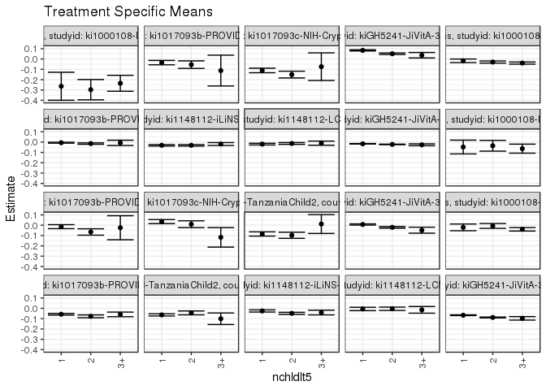

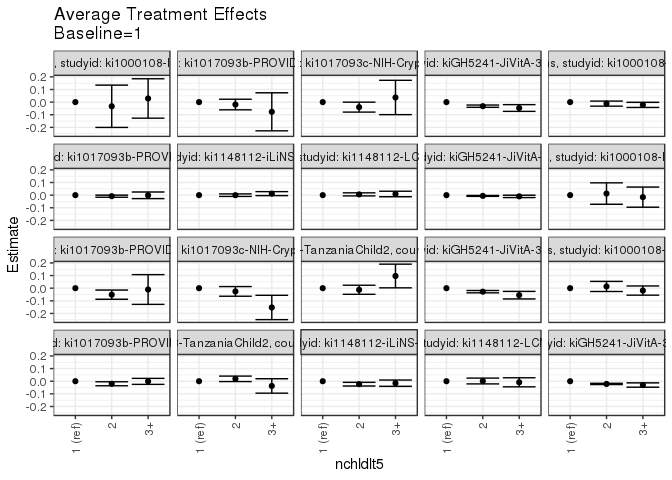

## Results Table

### Parameter: TSM

| diffcat | studyid | country | intervention_level | baseline_level | estimate | ci_lower | ci_upper |
| --- | --- | --- | --- | --- | --- | --- | --- |
| 0-3 months | ki1000108-IRC | INDIA | 1 | NA | -0.2641160 | -0.3997300 | -0.1285020 |
| 0-3 months | ki1000108-IRC | INDIA | 2 | NA | -0.2971800 | -0.3955571 | -0.1988028 |
| 0-3 months | ki1000108-IRC | INDIA | 3+ | NA | -0.2353764 | -0.3124153 | -0.1583375 |
| 0-3 months | ki1017093b-PROVIDE | BANGLADESH | 1 | NA | -0.0354425 | -0.0565857 | -0.0142994 |
| 0-3 months | ki1017093b-PROVIDE | BANGLADESH | 2 | NA | -0.0546259 | -0.0908762 | -0.0183756 |
| 0-3 months | ki1017093b-PROVIDE | BANGLADESH | 3+ | NA | -0.1123006 | -0.2613547 | 0.0367536 |
| 0-3 months | ki1017093c-NIH-Crypto | BANGLADESH | 1 | NA | -0.1111297 | -0.1331055 | -0.0891540 |
| 0-3 months | ki1017093c-NIH-Crypto | BANGLADESH | 2 | NA | -0.1510585 | -0.1836995 | -0.1184175 |
| 0-3 months | ki1017093c-NIH-Crypto | BANGLADESH | 3+ | NA | -0.0744920 | -0.2086389 | 0.0596549 |
| 0-3 months | kiGH5241-JiVitA-3 | BANGLADESH | 1 | NA | 0.0830089 | 0.0771722 | 0.0888457 |
| 0-3 months | kiGH5241-JiVitA-3 | BANGLADESH | 2 | NA | 0.0508623 | 0.0432827 | 0.0584420 |
| 0-3 months | kiGH5241-JiVitA-3 | BANGLADESH | 3+ | NA | 0.0364016 | 0.0099359 | 0.0628673 |
| 3-6 months | ki1000108-IRC | INDIA | 1 | NA | -0.0477002 | -0.1144155 | 0.0190151 |
| 3-6 months | ki1000108-IRC | INDIA | 2 | NA | -0.0351608 | -0.0875119 | 0.0171902 |
| 3-6 months | ki1000108-IRC | INDIA | 3+ | NA | -0.0634836 | -0.1071331 | -0.0198341 |
| 3-6 months | ki1017093b-PROVIDE | BANGLADESH | 1 | NA | -0.0141139 | -0.0336013 | 0.0053735 |
| 3-6 months | ki1017093b-PROVIDE | BANGLADESH | 2 | NA | -0.0655108 | -0.0962880 | -0.0347337 |
| 3-6 months | ki1017093b-PROVIDE | BANGLADESH | 3+ | NA | -0.0245420 | -0.1407561 | 0.0916720 |
| 3-6 months | ki1017093c-NIH-Crypto | BANGLADESH | 1 | NA | 0.0351356 | 0.0155221 | 0.0547491 |
| 3-6 months | ki1017093c-NIH-Crypto | BANGLADESH | 2 | NA | 0.0096440 | -0.0232636 | 0.0425517 |
| 3-6 months | ki1017093c-NIH-Crypto | BANGLADESH | 3+ | NA | -0.1176585 | -0.2120437 | -0.0232734 |
| 3-6 months | ki1066203-TanzaniaChild2 | TANZANIA, UNITED REPUBLIC OF | 1 | NA | -0.0849462 | -0.1053945 | -0.0644979 |
| 3-6 months | ki1066203-TanzaniaChild2 | TANZANIA, UNITED REPUBLIC OF | 2 | NA | -0.0975053 | -0.1270931 | -0.0679175 |
| 3-6 months | ki1066203-TanzaniaChild2 | TANZANIA, UNITED REPUBLIC OF | 3+ | NA | 0.0115521 | -0.0799479 | 0.1030521 |
| 3-6 months | kiGH5241-JiVitA-3 | BANGLADESH | 1 | NA | 0.0069463 | 0.0010922 | 0.0128003 |
| 3-6 months | kiGH5241-JiVitA-3 | BANGLADESH | 2 | NA | -0.0206328 | -0.0284671 | -0.0127985 |
| 3-6 months | kiGH5241-JiVitA-3 | BANGLADESH | 3+ | NA | -0.0483401 | -0.0772300 | -0.0194503 |
| 6-12 months | ki1000108-IRC | INDIA | 1 | NA | -0.0207662 | -0.0532856 | 0.0117531 |
| 6-12 months | ki1000108-IRC | INDIA | 2 | NA | -0.0070400 | -0.0304006 | 0.0163205 |
| 6-12 months | ki1000108-IRC | INDIA | 3+ | NA | -0.0396019 | -0.0563469 | -0.0228569 |
| 6-12 months | ki1017093b-PROVIDE | BANGLADESH | 1 | NA | -0.0575360 | -0.0657047 | -0.0493674 |
| 6-12 months | ki1017093b-PROVIDE | BANGLADESH | 2 | NA | -0.0775240 | -0.0910851 | -0.0639628 |
| 6-12 months | ki1017093b-PROVIDE | BANGLADESH | 3+ | NA | -0.0587582 | -0.0810157 | -0.0365007 |
| 6-12 months | ki1066203-TanzaniaChild2 | TANZANIA, UNITED REPUBLIC OF | 1 | NA | -0.0634676 | -0.0741955 | -0.0527397 |
| 6-12 months | ki1066203-TanzaniaChild2 | TANZANIA, UNITED REPUBLIC OF | 2 | NA | -0.0444780 | -0.0632095 | -0.0257466 |
| 6-12 months | ki1066203-TanzaniaChild2 | TANZANIA, UNITED REPUBLIC OF | 3+ | NA | -0.1008507 | -0.1568939 | -0.0448075 |
| 6-12 months | ki1148112-iLiNS-DOSE | MALAWI | 1 | NA | -0.0254660 | -0.0360463 | -0.0148857 |
| 6-12 months | ki1148112-iLiNS-DOSE | MALAWI | 2 | NA | -0.0487261 | -0.0587151 | -0.0387372 |
| 6-12 months | ki1148112-iLiNS-DOSE | MALAWI | 3+ | NA | -0.0410082 | -0.0636107 | -0.0184056 |
| 6-12 months | ki1148112-LCNI-5 | MALAWI | 1 | NA | -0.0062329 | -0.0225532 | 0.0100874 |
| 6-12 months | ki1148112-LCNI-5 | MALAWI | 2 | NA | -0.0045622 | -0.0208342 | 0.0117099 |
| 6-12 months | ki1148112-LCNI-5 | MALAWI | 3+ | NA | -0.0147704 | -0.0468983 | 0.0173574 |
| 6-12 months | kiGH5241-JiVitA-3 | BANGLADESH | 1 | NA | -0.0669255 | -0.0703920 | -0.0634591 |
| 6-12 months | kiGH5241-JiVitA-3 | BANGLADESH | 2 | NA | -0.0884249 | -0.0926389 | -0.0842108 |
| 6-12 months | kiGH5241-JiVitA-3 | BANGLADESH | 3+ | NA | -0.0971355 | -0.1139326 | -0.0803384 |
| 12-24 months | ki1000108-IRC | INDIA | 1 | NA | -0.0175297 | -0.0347781 | -0.0002812 |
| 12-24 months | ki1000108-IRC | INDIA | 2 | NA | -0.0294925 | -0.0398851 | -0.0191000 |
| 12-24 months | ki1000108-IRC | INDIA | 3+ | NA | -0.0394418 | -0.0498341 | -0.0290495 |
| 12-24 months | ki1017093b-PROVIDE | BANGLADESH | 1 | NA | -0.0059797 | -0.0106091 | -0.0013502 |
| 12-24 months | ki1017093b-PROVIDE | BANGLADESH | 2 | NA | -0.0142175 | -0.0211331 | -0.0073018 |
| 12-24 months | ki1017093b-PROVIDE | BANGLADESH | 3+ | NA | -0.0071792 | -0.0329060 | 0.0185477 |
| 12-24 months | ki1148112-iLiNS-DOSE | MALAWI | 1 | NA | -0.0308203 | -0.0377888 | -0.0238518 |
| 12-24 months | ki1148112-iLiNS-DOSE | MALAWI | 2 | NA | -0.0310215 | -0.0383679 | -0.0236750 |
| 12-24 months | ki1148112-iLiNS-DOSE | MALAWI | 3+ | NA | -0.0187522 | -0.0328014 | -0.0047031 |
| 12-24 months | ki1148112-LCNI-5 | MALAWI | 1 | NA | -0.0193914 | -0.0277237 | -0.0110591 |
| 12-24 months | ki1148112-LCNI-5 | MALAWI | 2 | NA | -0.0133266 | -0.0221463 | -0.0045069 |
| 12-24 months | ki1148112-LCNI-5 | MALAWI | 3+ | NA | -0.0102846 | -0.0303384 | 0.0097692 |
| 12-24 months | kiGH5241-JiVitA-3 | BANGLADESH | 1 | NA | -0.0164757 | -0.0189041 | -0.0140472 |
| 12-24 months | kiGH5241-JiVitA-3 | BANGLADESH | 2 | NA | -0.0223526 | -0.0250558 | -0.0196495 |
| 12-24 months | kiGH5241-JiVitA-3 | BANGLADESH | 3+ | NA | -0.0261935 | -0.0352375 | -0.0171495 |

### Parameter: E(Y)

| diffcat | studyid | country | intervention_level | baseline_level | estimate | ci_lower | ci_upper |
| --- | --- | --- | --- | --- | --- | --- | --- |
| 0-3 months | ki1000108-IRC | INDIA | NA | NA | -0.2594964 | -0.3154509 | -0.2035418 |
| 0-3 months | ki1017093b-PROVIDE | BANGLADESH | NA | NA | -0.0413143 | -0.0594662 | -0.0231624 |
| 0-3 months | ki1017093c-NIH-Crypto | BANGLADESH | NA | NA | -0.1220821 | -0.1402761 | -0.1038881 |
| 0-3 months | kiGH5241-JiVitA-3 | BANGLADESH | NA | NA | 0.0705498 | 0.0655945 | 0.0755050 |
| 3-6 months | ki1000108-IRC | INDIA | NA | NA | -0.0518918 | -0.0819849 | -0.0217987 |
| 3-6 months | ki1017093b-PROVIDE | BANGLADESH | NA | NA | -0.0272428 | -0.0436954 | -0.0107902 |
| 3-6 months | ki1017093c-NIH-Crypto | BANGLADESH | NA | NA | 0.0267740 | 0.0099602 | 0.0435879 |
| 3-6 months | ki1066203-TanzaniaChild2 | TANZANIA, UNITED REPUBLIC OF | NA | NA | -0.0855875 | -0.1022050 | -0.0689699 |
| 3-6 months | kiGH5241-JiVitA-3 | BANGLADESH | NA | NA | -0.0034268 | -0.0082920 | 0.0014385 |
| 6-12 months | ki1000108-IRC | INDIA | NA | NA | -0.0260151 | -0.0389122 | -0.0131180 |
| 6-12 months | ki1017093b-PROVIDE | BANGLADESH | NA | NA | -0.0626151 | -0.0695574 | -0.0556729 |
| 6-12 months | ki1066203-TanzaniaChild2 | TANZANIA, UNITED REPUBLIC OF | NA | NA | -0.0595549 | -0.0687696 | -0.0503402 |
| 6-12 months | ki1148112-iLiNS-DOSE | MALAWI | NA | NA | -0.0373553 | -0.0443239 | -0.0303868 |
| 6-12 months | ki1148112-LCNI-5 | MALAWI | NA | NA | -0.0060302 | -0.0170093 | 0.0049488 |
| 6-12 months | kiGH5241-JiVitA-3 | BANGLADESH | NA | NA | -0.0748335 | -0.0776775 | -0.0719894 |
| 12-24 months | ki1000108-IRC | INDIA | NA | NA | -0.0317687 | -0.0388357 | -0.0247017 |
| 12-24 months | ki1017093b-PROVIDE | BANGLADESH | NA | NA | -0.0081718 | -0.0120131 | -0.0043304 |
| 12-24 months | ki1148112-iLiNS-DOSE | MALAWI | NA | NA | -0.0300342 | -0.0348485 | -0.0252199 |
| 12-24 months | ki1148112-LCNI-5 | MALAWI | NA | NA | -0.0161503 | -0.0219777 | -0.0103229 |
| 12-24 months | kiGH5241-JiVitA-3 | BANGLADESH | NA | NA | -0.0187696 | -0.0206191 | -0.0169201 |

### Parameter: ATE

| diffcat | studyid | country | intervention_level | baseline_level | estimate | ci_lower | ci_upper |
| --- | --- | --- | --- | --- | --- | --- | --- |
| 0-3 months | ki1000108-IRC | INDIA | 1 | 1 | 0.0000000 | 0.0000000 | 0.0000000 |
| 0-3 months | ki1000108-IRC | INDIA | 2 | 1 | -0.0330640 | -0.2006027 | 0.1344747 |
| 0-3 months | ki1000108-IRC | INDIA | 3+ | 1 | 0.0287396 | -0.1272288 | 0.1847080 |
| 0-3 months | ki1017093b-PROVIDE | BANGLADESH | 1 | 1 | 0.0000000 | 0.0000000 | 0.0000000 |
| 0-3 months | ki1017093b-PROVIDE | BANGLADESH | 2 | 1 | -0.0191833 | -0.0611490 | 0.0227823 |
| 0-3 months | ki1017093b-PROVIDE | BANGLADESH | 3+ | 1 | -0.0768580 | -0.2274043 | 0.0736882 |
| 0-3 months | ki1017093c-NIH-Crypto | BANGLADESH | 1 | 1 | 0.0000000 | 0.0000000 | 0.0000000 |
| 0-3 months | ki1017093c-NIH-Crypto | BANGLADESH | 2 | 1 | -0.0399288 | -0.0792781 | -0.0005794 |
| 0-3 months | ki1017093c-NIH-Crypto | BANGLADESH | 3+ | 1 | 0.0366377 | -0.0992973 | 0.1725727 |
| 0-3 months | kiGH5241-JiVitA-3 | BANGLADESH | 1 | 1 | 0.0000000 | 0.0000000 | 0.0000000 |
| 0-3 months | kiGH5241-JiVitA-3 | BANGLADESH | 2 | 1 | -0.0321466 | -0.0410621 | -0.0232311 |
| 0-3 months | kiGH5241-JiVitA-3 | BANGLADESH | 3+ | 1 | -0.0466073 | -0.0732033 | -0.0200113 |
| 3-6 months | ki1000108-IRC | INDIA | 1 | 1 | 0.0000000 | 0.0000000 | 0.0000000 |
| 3-6 months | ki1000108-IRC | INDIA | 2 | 1 | 0.0125394 | -0.0722637 | 0.0973425 |
| 3-6 months | ki1000108-IRC | INDIA | 3+ | 1 | -0.0157834 | -0.0955092 | 0.0639425 |
| 3-6 months | ki1017093b-PROVIDE | BANGLADESH | 1 | 1 | 0.0000000 | 0.0000000 | 0.0000000 |
| 3-6 months | ki1017093b-PROVIDE | BANGLADESH | 2 | 1 | -0.0513969 | -0.0878248 | -0.0149690 |
| 3-6 months | ki1017093b-PROVIDE | BANGLADESH | 3+ | 1 | -0.0104281 | -0.1282648 | 0.1074085 |
| 3-6 months | ki1017093c-NIH-Crypto | BANGLADESH | 1 | 1 | 0.0000000 | 0.0000000 | 0.0000000 |
| 3-6 months | ki1017093c-NIH-Crypto | BANGLADESH | 2 | 1 | -0.0254916 | -0.0638009 | 0.0128177 |
| 3-6 months | ki1017093c-NIH-Crypto | BANGLADESH | 3+ | 1 | -0.1527942 | -0.2491956 | -0.0563927 |
| 3-6 months | ki1066203-TanzaniaChild2 | TANZANIA, UNITED REPUBLIC OF | 1 | 1 | 0.0000000 | 0.0000000 | 0.0000000 |
| 3-6 months | ki1066203-TanzaniaChild2 | TANZANIA, UNITED REPUBLIC OF | 2 | 1 | -0.0125591 | -0.0485253 | 0.0234071 |
| 3-6 months | ki1066203-TanzaniaChild2 | TANZANIA, UNITED REPUBLIC OF | 3+ | 1 | 0.0964983 | 0.0027412 | 0.1902554 |
| 3-6 months | kiGH5241-JiVitA-3 | BANGLADESH | 1 | 1 | 0.0000000 | 0.0000000 | 0.0000000 |
| 3-6 months | kiGH5241-JiVitA-3 | BANGLADESH | 2 | 1 | -0.0275790 | -0.0367871 | -0.0183710 |
| 3-6 months | kiGH5241-JiVitA-3 | BANGLADESH | 3+ | 1 | -0.0552864 | -0.0851035 | -0.0254693 |
| 6-12 months | ki1000108-IRC | INDIA | 1 | 1 | 0.0000000 | 0.0000000 | 0.0000000 |
| 6-12 months | ki1000108-IRC | INDIA | 2 | 1 | 0.0137262 | -0.0263141 | 0.0537665 |
| 6-12 months | ki1000108-IRC | INDIA | 3+ | 1 | -0.0188357 | -0.0554130 | 0.0177417 |
| 6-12 months | ki1017093b-PROVIDE | BANGLADESH | 1 | 1 | 0.0000000 | 0.0000000 | 0.0000000 |
| 6-12 months | ki1017093b-PROVIDE | BANGLADESH | 2 | 1 | -0.0199879 | -0.0358192 | -0.0041566 |
| 6-12 months | ki1017093b-PROVIDE | BANGLADESH | 3+ | 1 | -0.0012222 | -0.0249313 | 0.0224870 |
| 6-12 months | ki1066203-TanzaniaChild2 | TANZANIA, UNITED REPUBLIC OF | 1 | 1 | 0.0000000 | 0.0000000 | 0.0000000 |
| 6-12 months | ki1066203-TanzaniaChild2 | TANZANIA, UNITED REPUBLIC OF | 2 | 1 | 0.0189896 | -0.0025964 | 0.0405756 |
| 6-12 months | ki1066203-TanzaniaChild2 | TANZANIA, UNITED REPUBLIC OF | 3+ | 1 | -0.0373831 | -0.0944439 | 0.0196777 |
| 6-12 months | ki1148112-iLiNS-DOSE | MALAWI | 1 | 1 | 0.0000000 | 0.0000000 | 0.0000000 |
| 6-12 months | ki1148112-iLiNS-DOSE | MALAWI | 2 | 1 | -0.0232601 | -0.0378108 | -0.0087095 |
| 6-12 months | ki1148112-iLiNS-DOSE | MALAWI | 3+ | 1 | -0.0155422 | -0.0404985 | 0.0094142 |
| 6-12 months | ki1148112-LCNI-5 | MALAWI | 1 | 1 | 0.0000000 | 0.0000000 | 0.0000000 |
| 6-12 months | ki1148112-LCNI-5 | MALAWI | 2 | 1 | 0.0016708 | -0.0213755 | 0.0247170 |
| 6-12 months | ki1148112-LCNI-5 | MALAWI | 3+ | 1 | -0.0085375 | -0.0445729 | 0.0274979 |
| 6-12 months | kiGH5241-JiVitA-3 | BANGLADESH | 1 | 1 | 0.0000000 | 0.0000000 | 0.0000000 |
| 6-12 months | kiGH5241-JiVitA-3 | BANGLADESH | 2 | 1 | -0.0214993 | -0.0265977 | -0.0164010 |
| 6-12 months | kiGH5241-JiVitA-3 | BANGLADESH | 3+ | 1 | -0.0302100 | -0.0473692 | -0.0130508 |
| 12-24 months | ki1000108-IRC | INDIA | 1 | 1 | 0.0000000 | 0.0000000 | 0.0000000 |
| 12-24 months | ki1000108-IRC | INDIA | 2 | 1 | -0.0119629 | -0.0321003 | 0.0081746 |
| 12-24 months | ki1000108-IRC | INDIA | 3+ | 1 | -0.0219121 | -0.0420494 | -0.0017749 |
| 12-24 months | ki1017093b-PROVIDE | BANGLADESH | 1 | 1 | 0.0000000 | 0.0000000 | 0.0000000 |
| 12-24 months | ki1017093b-PROVIDE | BANGLADESH | 2 | 1 | -0.0082378 | -0.0165599 | 0.0000843 |
| 12-24 months | ki1017093b-PROVIDE | BANGLADESH | 3+ | 1 | -0.0011995 | -0.0273395 | 0.0249405 |
| 12-24 months | ki1148112-iLiNS-DOSE | MALAWI | 1 | 1 | 0.0000000 | 0.0000000 | 0.0000000 |
| 12-24 months | ki1148112-iLiNS-DOSE | MALAWI | 2 | 1 | -0.0002012 | -0.0103269 | 0.0099246 |
| 12-24 months | ki1148112-iLiNS-DOSE | MALAWI | 3+ | 1 | 0.0120681 | -0.0036144 | 0.0277505 |
| 12-24 months | ki1148112-LCNI-5 | MALAWI | 1 | 1 | 0.0000000 | 0.0000000 | 0.0000000 |
| 12-24 months | ki1148112-LCNI-5 | MALAWI | 2 | 1 | 0.0060648 | -0.0060684 | 0.0181980 |
| 12-24 months | ki1148112-LCNI-5 | MALAWI | 3+ | 1 | 0.0091068 | -0.0126092 | 0.0308227 |
| 12-24 months | kiGH5241-JiVitA-3 | BANGLADESH | 1 | 1 | 0.0000000 | 0.0000000 | 0.0000000 |
| 12-24 months | kiGH5241-JiVitA-3 | BANGLADESH | 2 | 1 | -0.0058770 | -0.0094445 | -0.0023094 |
| 12-24 months | kiGH5241-JiVitA-3 | BANGLADESH | 3+ | 1 | -0.0097178 | -0.0190919 | -0.0003437 |